# Problem set #3 - Vincentless

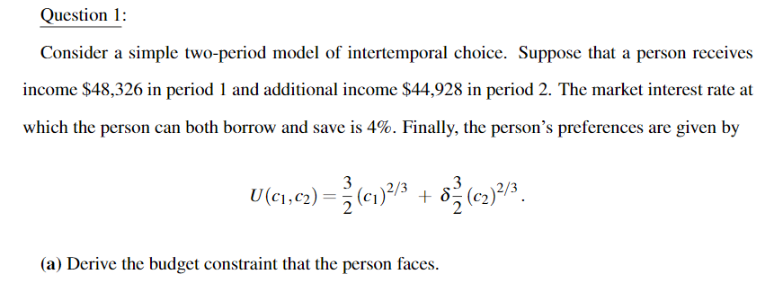

I assume they cannot borrow/save for more than one period, since then they would simply borrow an infinite amount of money in period 1 and never pay it back. The market interest rates mean that person can lose $X$ in period 1 and recieve $X*1.04$ in period 2, or gain $X$ in period 1 and lose $X*1.04$ in period 2. As such we get

$W(X) = (48,326+X;44,928-X*1.04) $

I can't quite remember the notation we used in class

We want to know when U is maximized. This is at the point when the change in U is zero, which means

$$ \frac{d}{dc_1} 3/2 c_1 ^{2/3} = \frac{d}{dc_2} 3/2\delta c_2 ^{2/3} \\ c_1^{-1/3} = \delta c_2^{-1/3} \\ c_1 = \sqrt[3]{\delta} c_2 \\ c_2 = \delta^3 c_1 $$

We can double check this with some arbitrary values. Lets say money can be transferred freely between both periods $$ \begin{cases} c_1 + c_2 = 100 \\ \delta = 0.5 \\ c_1(1.125)=100 \\ c_1 = 88.9,\ c_2 = 11.1\\ U = 33.61 \\ \end{cases}\\ \begin{cases} c_1 = c_2 = 50\\ U = 30.5 \\ \end{cases}\\ \begin{cases} c_1 = 88,\ c_2 = 11\\ U = 33.4 \end{cases} $$

Sweet

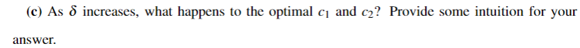

From our formula, it appears they will save more for period 2, $c_1$ decreases and $c_2$ increases. This makes sense, their utility function values the future more and so they will consume more in the future

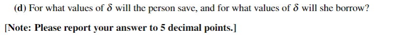

Okay lets put in our problem values

$$ X = c_1 -48326 \\ c_1 = X + 48326 \\ X = \frac{44928-c_2}{1.04} = \frac{44928-\delta^3 c_1}{1.04} = \frac{44928-\delta^3 (X + 48326)}{1.04} $$ For what value of $\delta$ does $X = 0$? $$ 0=44928-\delta^3\left(48326\right) \\ \delta^3 = \frac{44928}{48326} \\ \delta = \sqrt[3]{\frac{44928}{48326}} = 0.975990099509 $$ If $\delta$ is above 0.98, our friend will invest, or below will borrow

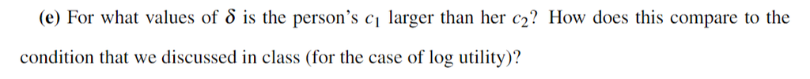

This is obvious if we think logically about the original utility function. I'm not sure if I was in class that day, and I'm too lazy to look through the slides to try to guess the correct answer

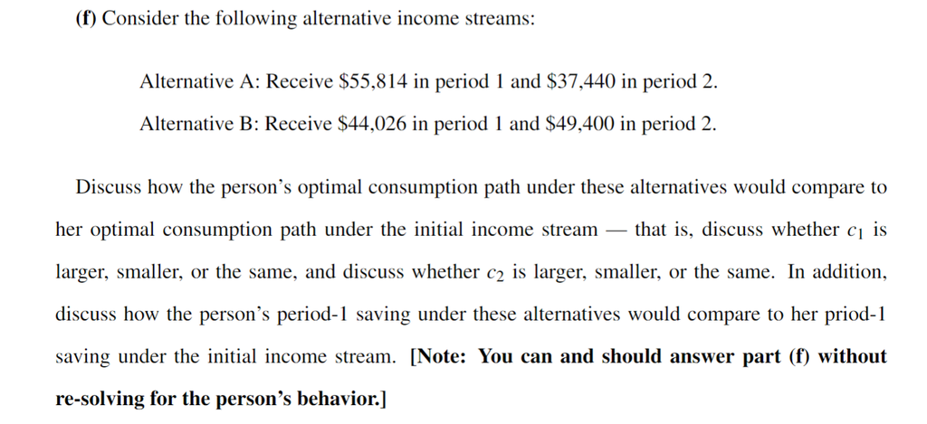

Uhh, don't we need $\delta$ for this? Nope! Just compare to conditions in intro to part 1

The second individual is likely to save more but is otherwise the same for the same reasons